# Analiza Mocy

Karol Szpyt

7 listopada 2018

### Pakiety

Poniżej wymienione są pakiety, które zostały użyte w tym badaniu.

```r
library(dplyr)
library(tidyr)
library(nortest)
library(tseries)
library(ggplot2)
library(reshape2)
library(tidyverse)
library(kableExtra)
library(Hmisc)
```

### Wstęp

W badaniu użyte zostały następujące testy:

- test Shapiro Wilka- test bazuje na wykresach typu kwantyl-kwantyl
- test Lillieforsa- test bada różnice między dystrybuantą empiryczną a teoretyczną. Jest to modyfikacja testu Kołmogorowa-Smirnowa. W przeciwiństwie do KS testu nie potrzebna jest informacja o śreniej oraz odchyleniu standardowym badanej próby.
- test Jarque- Bera
- test Pearson’a
- test Andersona-Darlinga- test bazujący na różnicach między dystrybuantami

Badanie przeprowadzone zostanie poprzez empiryczne wyznaczenie mocy poszczególnych testów. Wyniki następnie zostaną porównane.  
Mocą testu jest prawdopodobieństwo niepopełnienia błędu drugiego rodzaju. W przypadku tego badania sprowadza się to do zliczenia ile razy dany test odrzucił hipotezę zerową mówiącą o normalności rozkładu.

### Hipoteza

#### Dystrybuanta

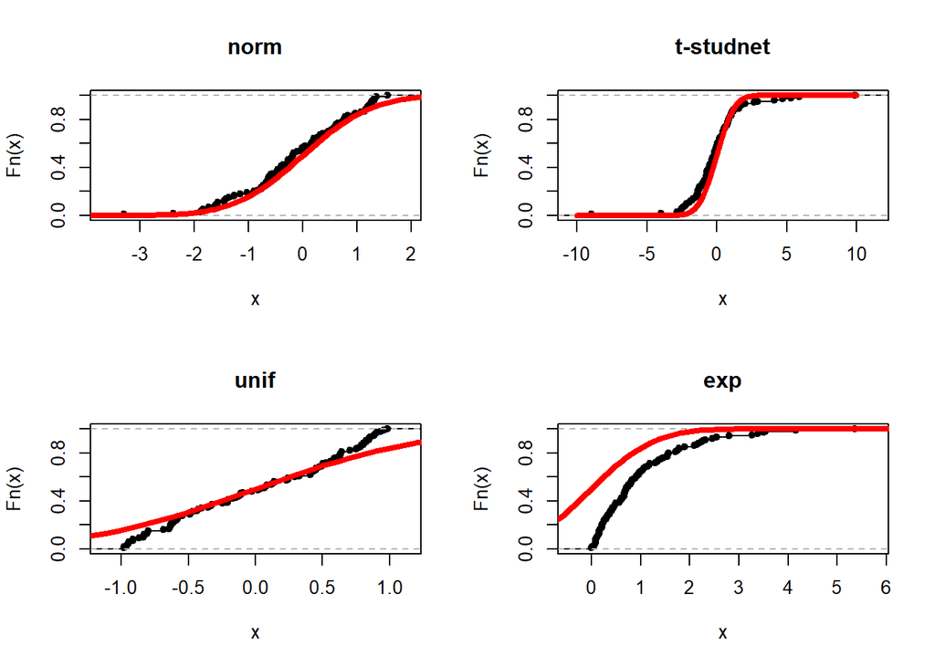

Czerwoną linią zaznaczona jest teoretyczna dystybuanta rozkładu normalnego. Na czarno widnieją dystybuanty wyliczone bezpośrednio z próby (100 elementowej) dzięki funkcji **ecdf()** z pakietu Hmisc.

#### Gęstość

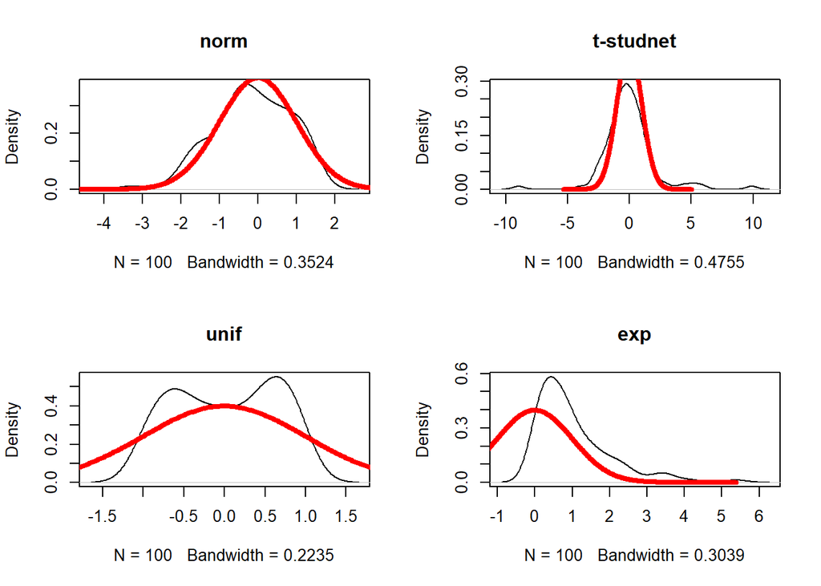

Podobna sytuacja co wyżej, z tym że dotycząca gęstości.

Spodziwanym wynikiem jest tendencja wzrostowa mocy testów wraz ze zwiększaniem liczbeności próby.  
Ponadto po przyjrzeniu się powyższym wykresom można będzie sie spodziewać, że testy najczęściej mylić się będą przy badaniu próby pochodzącej z rozkładu t-studenta co skutkować powinno zmniejszoną mocą testu.

### Badanie

Liczba symulacji ustawiona została na 1000 powtórzeń, a poziom istotności na 5%.

```r
len <- c(10, 20, 50, 70, 100, 125, 175, 200)
sym <- 1000
alpha <- 0.05
```

Funckja losująca próbę (jednocześnie ze wszystkich trzech rozkładów):

```r
gen <- function(y)
{
  dane <- lapply(y, function(x)
  {
    list("ts" = rt(x, 2),
         "unif" = runif(x, -1, 1),
         "exp" = rexp(x, 1)
    )

  })
  return(dane)
}
```

Wykorzystana następnie w głównej części pracy, czyli pętli obliczającej p-value ze wszystkich testów

```r
df <- data.frame()
for (a in len)
{
  for (b in 1:sym)
  {
    data <- gen(a)
    pvalues <- lapply(data[[1]], function(x)
    {
      list(
           "sw" = shapiro.test(x)$p.value,
           "jb" = jarque.bera.test(x)$p.value,
           "li" = lillie.test(x)$p.value,
           "chi" = pearson.test(x)$p.value,
           "ad" = ad.test(x)$p.value)
    })
    df <- rbind(df, c(as.data.frame(pvalues), "length" = a))

  }
}
```

### Empirycznie wyznaczone moce testów

Po uporządkowaniu danych przedstawiają się one następująco.  
Przypomnienie oznaczeń:

- **ts** - rozkład t-studenta
- **unif**- rozkład jednostajny
- **exp** - rozkład wykładniczy
- **sw** - test Shapiro-Wilka
- **li** - test Lilliefors’a
- **jb** - test Jarque-Bera
- **chi** - test Pearsona
- **ad** - test Anderson-Darling’a

|  | wielkość próbki- 10 sw | wielkość próbki- 10 jb | wielkość próbki- 10 li | wielkość próbki- 10 chi | wielkość próbki- 10 ad |
| --- | --- | --- | --- | --- | --- |
| ts | 0.312 | 0.191 | 0.271 | 0.24 | 0.309 |
| unif | 0.075 | 0.003 | 0.063 | 0.088 | 0.074 |
| exp | 0.436 | 0.145 | 0.301 | 0.406 | 0.41 |

|  | wielkość próbki- 20 sw | wielkość próbki- 20 jb | wielkość próbki- 20 li | wielkość próbki- 20 chi | wielkość próbki- 20 ad |
| --- | --- | --- | --- | --- | --- |
| ts | 0.544 | 0.503 | 0.456 | 0.341 | 0.535 |
| unif | 0.197 | 0.002 | 0.095 | 0.076 | 0.157 |
| exp | 0.84 | 0.464 | 0.56 | 0.644 | 0.77 |

|  | wielkość próbki- 50 sw | wielkość próbki- 50 jb | wielkość próbki- 50 li | wielkość próbki- 50 chi | wielkość próbki- 50 ad |
| --- | --- | --- | --- | --- | --- |
| ts | 0.865 | 0.867 | 0.771 | 0.654 | 0.863 |
| unif | 0.755 | 0 | 0.246 | 0.184 | 0.587 |
| exp | 0.999 | 0.937 | 0.956 | 0.983 | 0.998 |

|  | wielkość próbki- 70 sw | wielkość próbki- 70 jb | wielkość próbki- 70 li | wielkość próbki- 70 chi | wielkość próbki- 70 ad |
| --- | --- | --- | --- | --- | --- |
| ts | 0.943 | 0.947 | 0.879 | 0.779 | 0.932 |
| unif | 0.933 | 0.031 | 0.386 | 0.269 | 0.794 |
| exp | 1 | 0.994 | 0.996 | 0.999 | 1 |

|  | wielkość próbki- 100 sw | wielkość próbki- 100 jb | wielkość próbki- 100 li | wielkość próbki- 100 chi | wielkość próbki- 100 ad |
| --- | --- | --- | --- | --- | --- |
| ts | 0.984 | 0.985 | 0.947 | 0.883 | 0.982 |
| unif | 0.993 | 0.569 | 0.591 | 0.463 | 0.952 |
| exp | 1 | 1 | 1 | 1 | 1 |

|  | wielkość próbki- 125 sw | wielkość próbki- 125 jb | wielkość próbki- 125 li | wielkość próbki- 125 chi | wielkość próbki- 125 ad |
| --- | --- | --- | --- | --- | --- |
| ts | 0.994 | 0.993 | 0.981 | 0.934 | 0.994 |
| unif | 0.999 | 0.899 | 0.738 | 0.62 | 0.992 |
| exp | 1 | 1 | 1 | 1 | 1 |

|  | wielkość próbki- 175 sw | wielkość próbki- 175 jb | wielkość próbki- 175 li | wielkość próbki- 175 chi | wielkość próbki- 175 ad |
| --- | --- | --- | --- | --- | --- |
| ts | 1 | 1 | 0.998 | 0.979 | 1 |
| unif | 1 | 0.999 | 0.913 | 0.843 | 1 |
| exp | 1 | 1 | 1 | 1 | 1 |

|  | wielkość próbki- 200 sw | wielkość próbki- 200 jb | wielkość próbki- 200 li | wielkość próbki- 200 chi | wielkość próbki- 200 ad |
| --- | --- | --- | --- | --- | --- |
| ts | 1 | 0.999 | 0.999 | 0.996 | 1 |
| unif | 1 | 1 | 0.96 | 0.91 | 1 |
| exp | 1 | 1 | 1 | 1 | 1 |

Powyższe tabele prezentują moce testów w zależności poszczególnych czynników.  
Poniżej wizualizacja powyższych wyników na wykresach

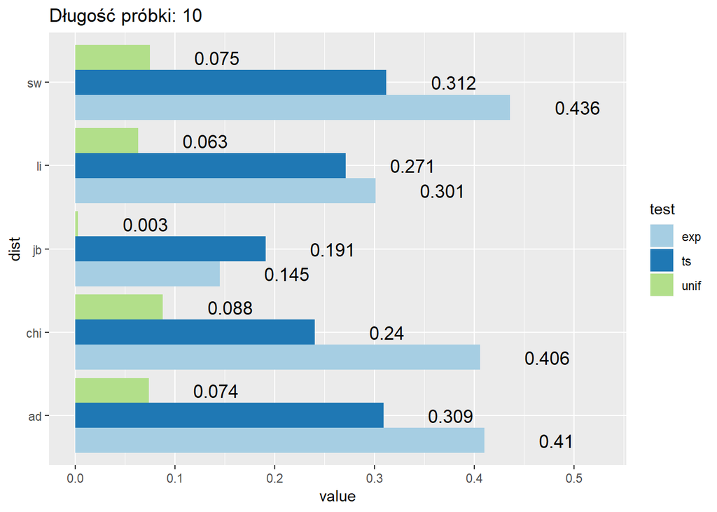

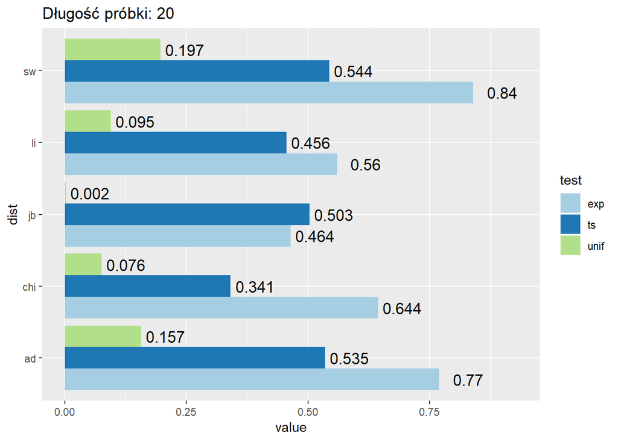

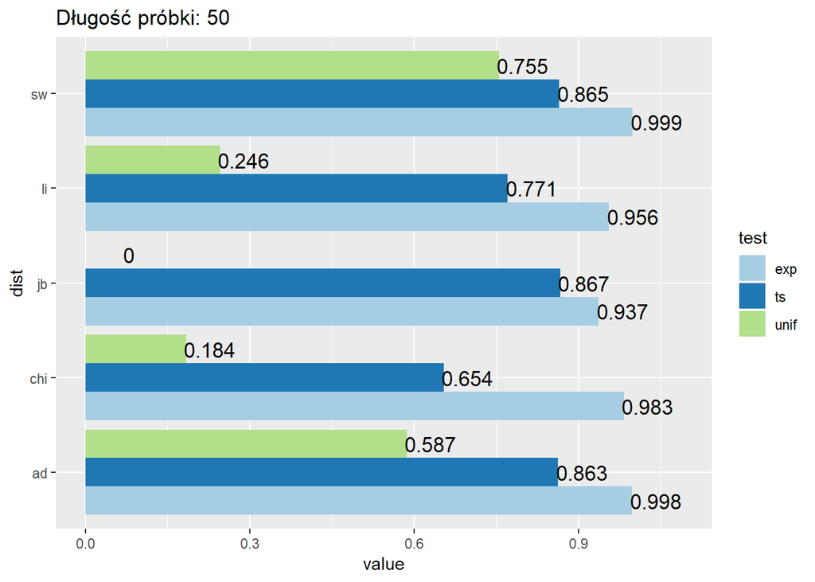

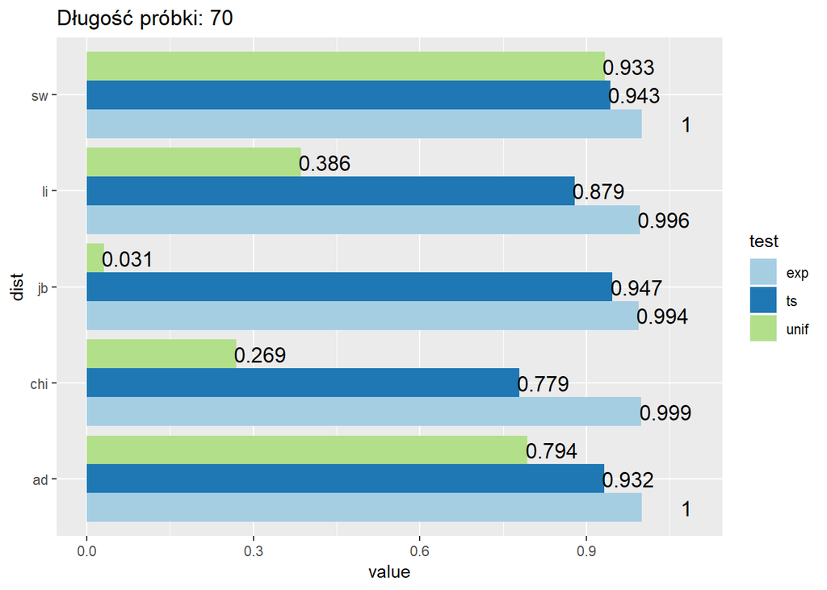

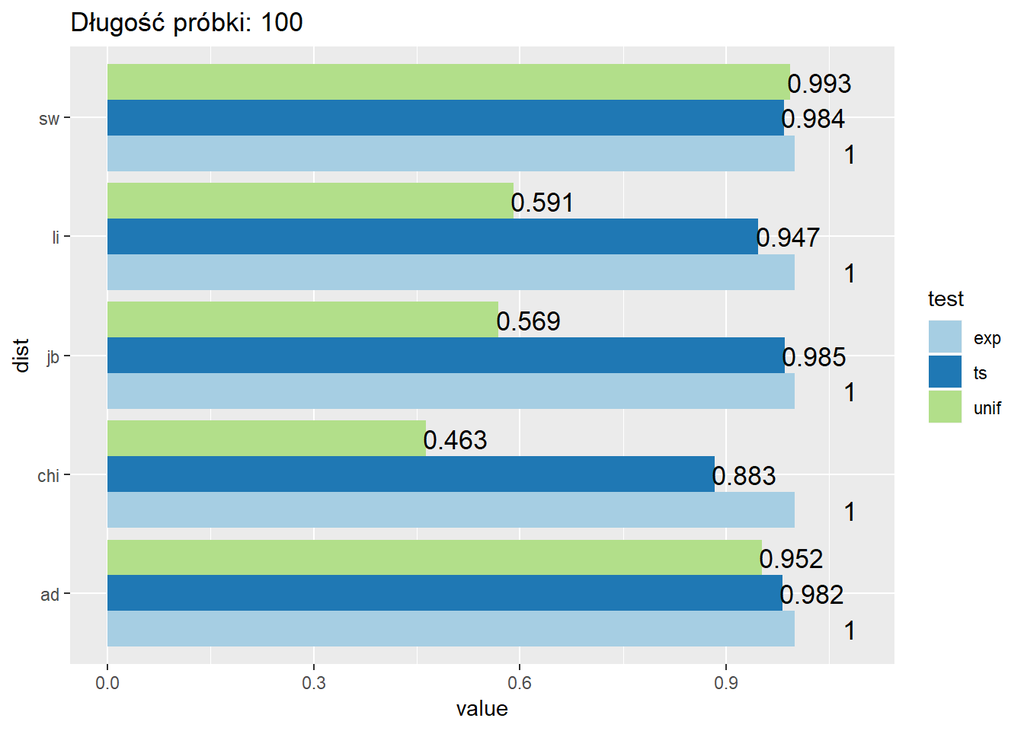

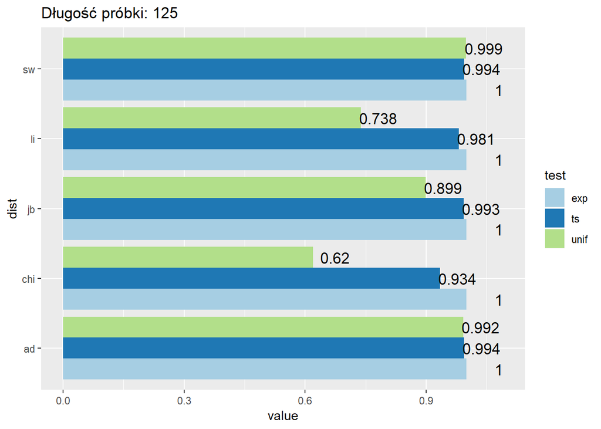

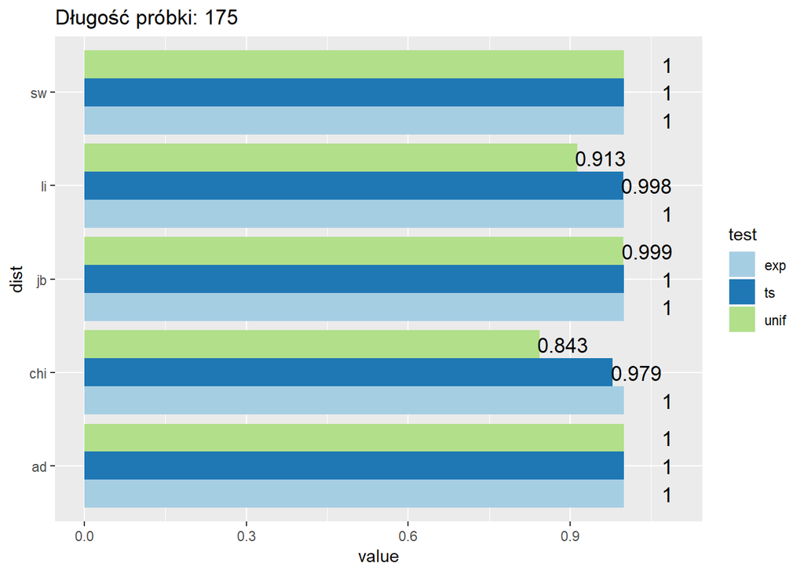

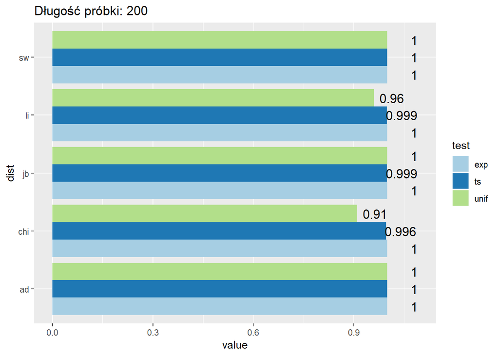

### Wnioski

Patrząc na kolejne wykresy od razu można stwierdzić że wraz ze wzrostem liczebności próby moc testu się zwiększa. Nie jest to nic zaskakującęgo.

#### Rozkład jednostajny

Przy małych próbach wszystkie testy mają bardzo niską moc w porównaniu do innych rozkładów. Różnice widać dopiero dla próby 50 elementowej, gdzie ponownie testy Shapiro-Wika oraz Andersona-Darlinga wyróżniają się większą mocą w porównaniu do pozostałych testów. Moce testów wyrównują się w okolicach maksymalnej wartości dopiero przy 200 elementowej próbie. Jest to niespodziewany efekt. Takiej sytuacji spodziewano się przy rozkładzie t-studenta.

#### Rozkład wykładniczy

Bez większych niespodzianek, dla małych prób ponownie najlepsze okazały się testy Shapiro-Wika oraz Andersona-Darlinga. Okolice maksymalnych wartości mocy wszystkich badanych testów uzyskano już przy próbie liczącej 50 elementów.